# Intro R

Witek ten Hove

19-12-2018

## Story

How can we help Lara to do her work more efficiently and generate better insights?

## Load libraries

We will be using some functions that are not part of the base R installation by loading the packages that contain them. For that we’ll use the `library()` function.

```r
library(gsheet)
library(tidyverse)
library(plotly)
```

## Read data

The data is gathered using Google Forms. We can read this data directly from the source.

```r
rawDF <- gsheet2tbl("https://docs.google.com/spreadsheets/d/1sZLHr2ebgieI9Qw3WDY4YFP0zKOMVSEbthdwjPobghE/edit?usp=sharing")[-1]
head(rawDF)
```

| id | month | year | value | date |
| --- | --- | --- | --- | --- |
| EU1 | 1 | 2015 | 0.3 | 2015-01-01 |
| EU1 | 2 | 2015 | 0.4 | 2015-02-01 |
| EU1 | 3 | 2015 | 0.0 | 2015-03-01 |
| EU1 | 4 | 2015 | 0.0 | 2015-04-01 |
| EU1 | 5 | 2015 | -0.1 | 2015-05-01 |
| EU1 | 6 | 2015 | 0.3 | 2015-06-01 |

## Assess data quality

We can view the first few rows and get some basic statistical parameters (central tendency and spread).

```r
head(rawDF)
```

| id | month | year | value | date |
| --- | --- | --- | --- | --- |
| EU1 | 1 | 2015 | 0.3 | 2015-01-01 |
| EU1 | 2 | 2015 | 0.4 | 2015-02-01 |
| EU1 | 3 | 2015 | 0.0 | 2015-03-01 |
| EU1 | 4 | 2015 | 0.0 | 2015-04-01 |
| EU1 | 5 | 2015 | -0.1 | 2015-05-01 |
| EU1 | 6 | 2015 | 0.3 | 2015-06-01 |

```r
summary(rawDF)
```

```
      id                month            year          value           date
 Length:504         Min.   : 1.00   Min.   :2015   Min.   :-0.20   Length:504
 Class :character   1st Qu.: 3.75   1st Qu.:2016   1st Qu.: 0.70   Class :character
 Mode  :character   Median : 6.50   Median :2018   Median : 1.30   Mode  :character
                    Mean   : 6.50   Mean   :2018   Mean   : 1.38
                    3rd Qu.: 9.25   3rd Qu.:2020   3rd Qu.: 1.77
                    Max.   :12.00   Max.   :2021   Max.   : 4.00
                                                   NA's   :240
```

The first column (variable) contains strings (type = `chr`). Most likely they are the IDs of the different facilities. We will change this type into categorical. Using the function `levels()` we can check all the different IDs. Apparently Lara added targets to the data.

We should also change the format of the columns with dates to type date`. Otherwise it will be handled as text data.

```r
rawDF$id <- as.factor(rawDF$id)
levels(rawDF$id)
```

```
[1] "EU1"    "EU2"    "Target" "USA1"   "USA2"   "USA3"
```

```r
rawDF$date <- as.Date(rawDF$date)
str(rawDF)
```

```
Classes ‘tbl_df’, ‘tbl’ and 'data.frame':   504 obs. of  5 variables:
 $ id   : Factor w/ 6 levels "EU1","EU2","Target",..: 1 1 1 1 1 1 1 1 1 1 ...
 $ month: num  1 2 3 4 5 6 7 8 9 10 ...
 $ year : num  2015 2015 2015 2015 2015 ...
 $ value: num  0.3 0.4 0 0 -0.1 0.3 0.3 0.7 0.5 0.5 ...
 $ date : Date, format: "2015-01-01" ...
```

## Visualization

Now we can inspect the data visually. First we’ll look at the data of one facility.

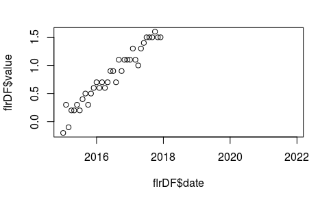

```r
flrDF <- filter(rawDF, id == "USA1")
plot(flrDF$date, flrDF$value)
```

Although informative the visualization is rather unattractive. The pacakge `ggplot2` (part of `tidyverse`) has functions for building nice visualizations. We will plot all data in one chart.

```r
p <- ggplot(rawDF) +
  geom_line(aes(x = date, y = value, group = id, color = id)) +
  ylim(0, 4) +
  scale_y_continuous(name = "level", breaks=c(1, 2, 3, 4), labels = c("BASIC", "DEVELOPMENT",
                                                                         "MATURITY", "EXCELLENCE"))
```

[output not shown]

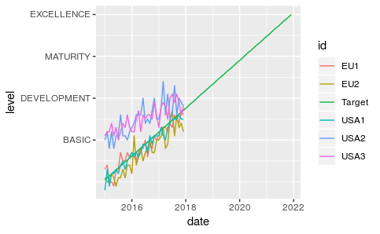

```r
p
```

Using the package `plotly` we can add interaction (move the cursor over the chart).

```r
ggplotly(p)
```

[interactive chart not shown]